# Statistics

Joy Kumagai

8/14/2020

## Purpose:

*This document will take you through the statistical procedures used to produce the results in Hsu et al. “Driven by drones: Improving mangrove extent maps using high-resolution remote sensing”*

## Upload Data

```r
data <- read.csv("../Data/Satellite.csv")
data_drone <- read.csv("../Data/Drone_4.1.csv")
data_drone <- data_drone %>%
  filter(TotalFishnetArea_1 > 0)
```

## Statistics for Satellite data (100 ha)

### Total Mangrove Area Basic stats

Sum of mangrove area (ha) measured by CONABIO

```
## [1] 26843.66
```

Sum of mangrove area (ha) measured by GMW

```
## [1] 34052.54
```

Total area of mangroves identified by either CONABIO or GMW (ha)

```
## [1] 35200.97
```

Sum of mangrove area that matched between CONABIO and GMW (ha)

```
## [1] 25695.23
```

### Comparison between CONABIO and GMW

Formatting data

```r
se <- function(x) sd(x)/sqrt(length(x)) #Standard Error function
d1 <- data %>%
  select(Area_not_overlapped, Area_overlap)
colnames(d1) <- c("Non_Overlapping_Area", "Overlapping_Area")
d1 <- d1 %>%
  gather(key = "category", value="area", Non_Overlapping_Area:Overlapping_Area)
```

```r
table1 <- d1 %>%
  group_by(category) %>%
  summarize(Mean = mean(area),
            Min = min(area),
            Max = max(area),
            StandardError = se(area))
kable(table1, caption = "Comparison between overlapping and non-overlapping areas (ha)") %>%
   kable_styling(full_width=F, position="left")
```

Comparison between overlapping and non-overlapping areas (ha)

| category | Mean | Min | Max | StandardError |
| --- | --- | --- | --- | --- |
| Non_Overlapping_Area | 5.664925 | 1.08e-05 | 71.82421 | 0.1451855 |
| Overlapping_Area | 15.313007 | 0.00e+00 | 96.60805 | 0.4748198 |

*Test for comparison between means of CONABIO and GMW*

Assumptions for paired t test are as follows:

1. The sampling units are randomly sampled from the population
2. The paired differences have a normal distribution in the population

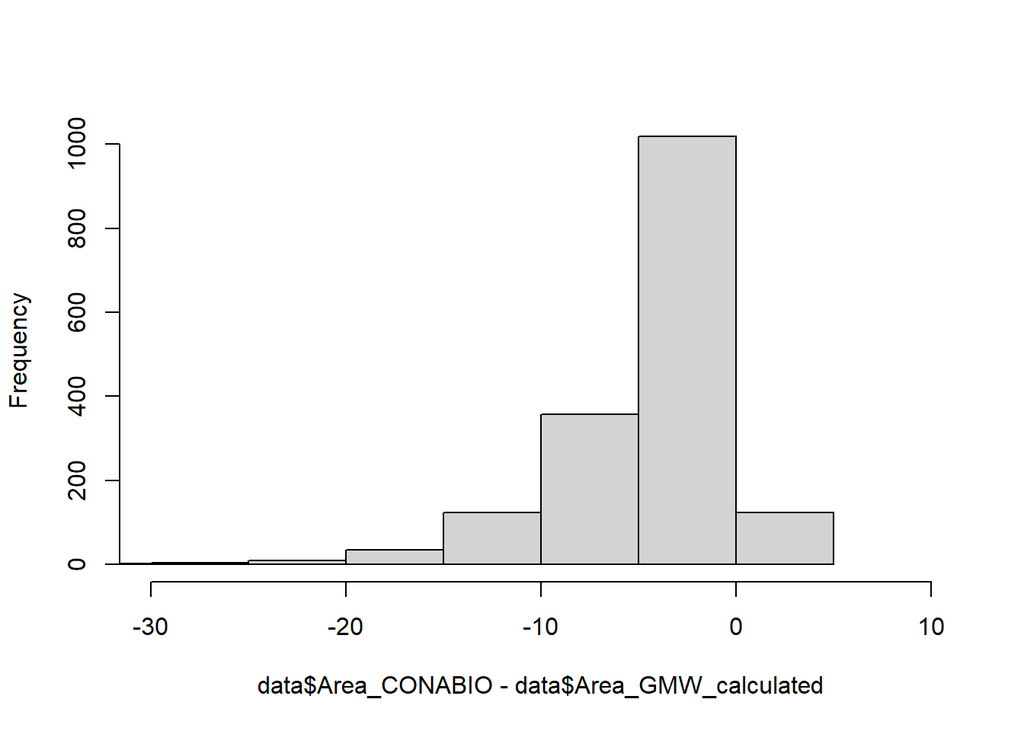

```r
hist(data$Area_CONABIO - data$Area_GMW_calculated, xlim=c(-30,10),
     main = "")
```

Not normally distributed so we used the wilcoxon test. (Figure 1B)

```r
wilcox.test(data$Area_CONABIO, data$Area_GMW_calculated, paired = TRUE) #used because we have a non normal distribution
```

```
##
##  Wilcoxon signed rank test with continuity correction
##
## data:  data$Area_CONABIO and data$Area_GMW_calculated
## V = 36794, p-value < 2.2e-16
## alternative hypothesis: true location shift is not equal to 0
```

### Linear Regression for Figure 1B

Regression summary.

```r
#Formatting Data
my_data <- data.frame(data$Area_total, data$Area_overlap, data$Area_CONABIO, data$Area_GMW_calculated)
colnames(my_data) <- c("Area_total", "Area_overlap", "Area_CONABIO", "Area_GMW")


model_plot1_B <- lm(data = my_data, Area_GMW ~ Area_CONABIO) #Same regression as the plot below
summary(model_plot1_B)
```

```
##
## Call:
## lm(formula = Area_GMW ~ Area_CONABIO, data = my_data)
##
## Residuals:
##     Min      1Q  Median      3Q     Max
## -10.314  -2.576  -1.274   1.114  69.028
##
## Coefficients:
##              Estimate Std. Error t value Pr(>|t|)
## (Intercept)  2.796449   0.164661   16.98   <2e-16 ***
## Area_CONABIO 1.093744   0.006479  168.80   <2e-16 ***
## ---
## Signif. codes:  0 '***' 0.001 '**' 0.01 '*' 0.05 '.' 0.1 ' ' 1
##
## Residual standard error: 5.241 on 1676 degrees of freedom
## Multiple R-squared:  0.9444, Adjusted R-squared:  0.9444
## F-statistic: 2.849e+04 on 1 and 1676 DF,  p-value: < 2.2e-16
```

Figure 1

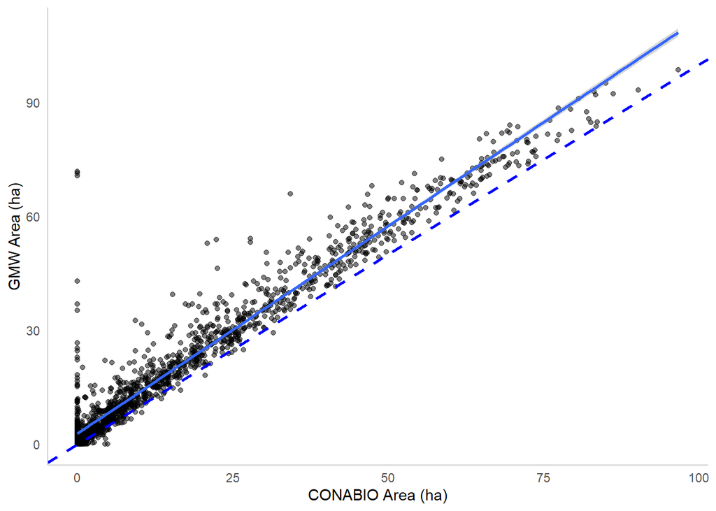

```r
plot1_A <- ggplot(data=my_data, aes(x=Area_CONABIO, y=Area_GMW)) +
  geom_point(alpha=0.5) +
  geom_abline(intercept = 0, color="blue", linetype="dashed", size=1) +
  geom_smooth(method = "lm") +
  labs(x="CONABIO Area (ha)", y="GMW Area (ha)") +
  theme_minimal() +
  theme(panel.grid.major = element_blank(),
        panel.grid.minor = element_blank(),
        axis.line = element_line(colour = "darkgrey", size=0.3))
plot1_A
```

### Disagreements in Area

Figure 2

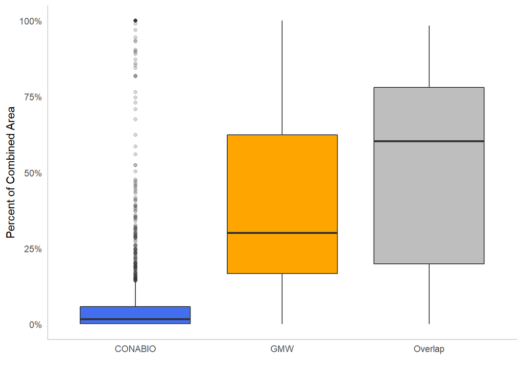

```r
colnames(data)[1] <- "ID"
plot2_data <- data %>%
  select(Area_total, Area_JCONABIO, Area_JGMW, ID, Percent_overlap) %>%
  rename(Overlap = Percent_overlap) %>%
  mutate(CONABIO = Area_JCONABIO/Area_total,
         GMW = Area_JGMW/Area_total) %>%
  gather(key="key", value="percent_area",Overlap:GMW)
plot2 <- plot2_data %>%
  ggplot(aes(x=key, y=percent_area, fill=key)) +
  geom_boxplot(outlier.alpha = 0.2) +
  labs(y="Percent of Combined Area", x="") +
  theme_minimal() +
  theme(legend.position="none",
        panel.grid.major = element_blank(),
        panel.grid.minor = element_blank(),
        axis.line = element_line(colour = "darkgrey", size=0.3)) +
  scale_y_continuous(labels = function(x) paste0(x*100, "%")) +
  scale_fill_manual(values=c("royalblue2", "orange", "grey"))
plot2
```

Comparison between the area identifed only by each data source and the area identified by both (overlap).

```r
table_plot2 <- plot2_data %>%
  group_by(key) %>%
  summarise(Mean = mean(percent_area), StandardError = se(percent_area))
kable(table_plot2, caption = "Mean refers to the area") %>%
   kable_styling(full_width=F, position="left")
```

Mean refers to the area

| key | Mean | StandardError |
| --- | --- | --- |
| CONABIO | 0.0682745 | 0.0038265 |
| GMW | 0.4249071 | 0.0080445 |
| Overlap | 0.5068178 | 0.0078433 |

Difference between the mean area identified by GMW and CONABIO.

```
##        Mean
## 1 0.3566326
```

Figure 3 - Jaccard’s Index

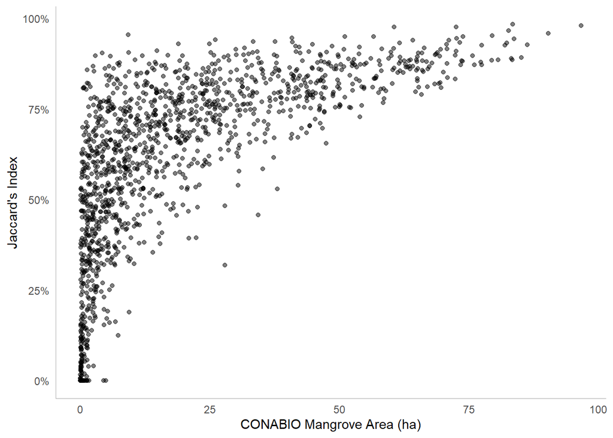

```r
plot3 <- data %>%
  select(Percent_overlap, Area_total, Area_CONABIO, Area_GMW_calculated) %>%
  ggplot(aes(x=Area_CONABIO, y=Percent_overlap)) +
  geom_point(alpha=0.5)+
  labs(x="CONABIO Mangrove Area (ha)", y="Jaccard's Index") +
  scale_y_continuous(labels = function(x) paste0(x*100, "%"))  +
  theme_minimal() +
  theme(panel.grid.major = element_blank(),
        panel.grid.minor = element_blank(),
        axis.line = element_line(colour = "darkgrey", size=0.3))
plot3
```

## Statistics for Drone Data vs. Satellite (1ha) - Section 3.2

### Drone Mangrove Area and agreement

```r
colnames(data_drone)[1] <- "UID"
d2_B <- data_drone %>%
  select(UID, TotalFishnetArea_1, Area_ha_drone:Area_ha_GMW) %>%
  rename(CONABIO = Area_ha_CONABIO,
         GMW = Area_ha_GMW,
         DRONE = Area_ha_drone) %>%
  gather(key = "key", value = "Area", DRONE:GMW)
table_DS <- d2_B %>%
  group_by(key) %>%
  summarize(Total_Area = sum(Area),
            Mean = mean(Area),
            StandardError = se(Area),
            Variance = var(Area))
kable(table_DS, caption = "Total area identified by each source (ha)") %>%
   kable_styling(full_width=F, position="left")
```

Total area identified by each source (ha)

| key | Total_Area | Mean | StandardError | Variance |
| --- | --- | --- | --- | --- |
| CONABIO | 232.3221 | 0.4302261 | 0.0164738 | 0.1465479 |
| DRONE | 206.0491 | 0.3815724 | 0.0151470 | 0.1238933 |
| GMW | 294.3214 | 0.5450397 | 0.0165224 | 0.1474142 |

### ANOVA test to compare means

```r
# Compute the analysis of variance
anova <- aov(Area ~ key, data = d2_B)
# Summary of the analysis
summary(anova)
```

```
##               Df Sum Sq Mean Sq F value   Pr(>F)
## key            2   7.61   3.804   27.31 2.16e-12 ***
## Residuals   1617 225.22   0.139
## ---
## Signif. codes:  0 '***' 0.001 '**' 0.01 '*' 0.05 '.' 0.1 ' ' 1
```

```r
# Detailed analyis of which pairs are significant
TukeyHSD(anova)
```

```
##   Tukey multiple comparisons of means
##     95% family-wise confidence level
##
## Fit: aov(formula = Area ~ key, data = d2_B)
##
## $key
##                      diff         lwr         upr     p adj
## DRONE-CONABIO -0.04865376 -0.10193490 0.004627378 0.0818422
## GMW-CONABIO    0.11481356  0.06153242 0.168094699 0.0000014
## GMW-DRONE      0.16346732  0.11018618 0.216748461 0.0000000
```

From these results we find that the Drone and CONABIO data are not significantly different, but the mean of GMW is significantly different compared to the drone data and CONABIO data.

## Root Mean Squared Estimate Calculation (RMSE)

The RMSE is used to understand how much the satellite measurements of the same area of mangrove differ from the drone measurements of the same area.

```r
d2 <- data_drone %>%
  select(UID, TotalFishnetArea_1, Area_ha_drone:Area_ha_GMW) %>%
  rename(CONABIO = Area_ha_CONABIO,
         GMW = Area_ha_GMW) %>%
  gather(key = "key", value = "Area", CONABIO:GMW) %>%
  mutate(difference = abs(Area_ha_drone - Area))
# Using the full dataset
d4 <- d2 %>% # General mean squared difference
  mutate(squared_residual = difference^2) %>%
  group_by(key) %>%
  summarise(RMSE = sqrt(mean(squared_residual)))
# Square of the standard error
kable(d4, caption = "The Root Mean Square Estimates") %>%
   kable_styling(full_width=F, position="left")
```

The Root Mean Square Estimates

| key | RMSE |
| --- | --- |
| CONABIO | 0.1417115 |
| GMW | 0.2391558 |

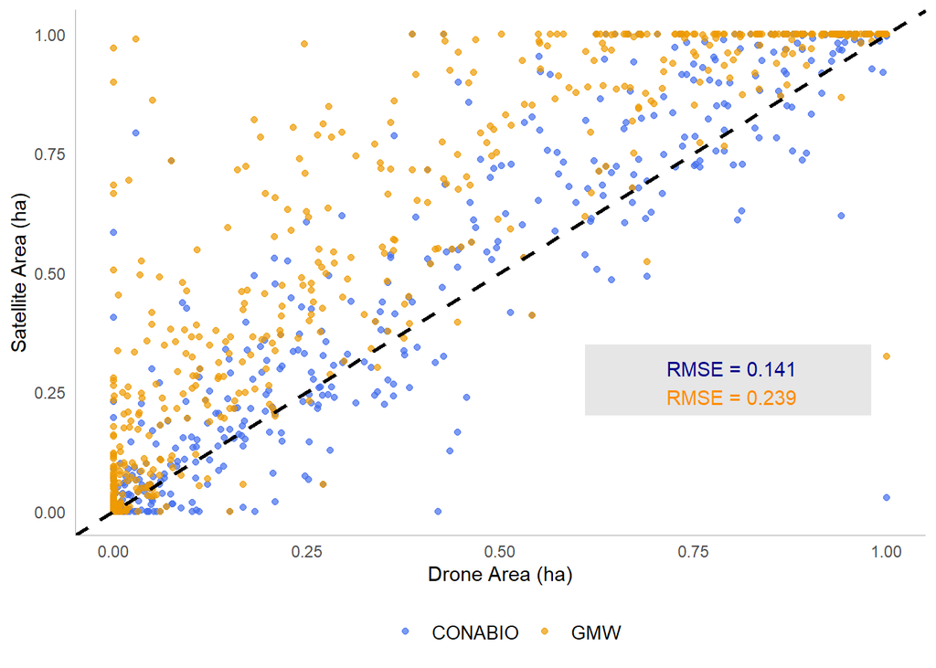

```r
plot5 <- data_drone %>%
  select(UID, TotalFishnetArea_1, Area_ha_drone:Area_ha_GMW) %>%
  rename(CONABIO = Area_ha_CONABIO,
         GMW = Area_ha_GMW) %>%
  gather(key = "key", value = "Area", CONABIO:GMW) %>%
  ggplot(aes(x=Area_ha_drone, y=Area, color=key)) +
  geom_point(alpha=0.7) +
  geom_abline(intercept = 0, color="black", linetype="dashed", size=1) +
  # geom_smooth(aes(x=Area_ha_drone, y=fitted_values, color=key)) +
  scale_color_manual(values = c("royalblue2", "orange2")) +
  ylim(0,1.001) +
  labs(x="Drone Area (ha)", y="Satellite Area (ha)") +
  theme_minimal() +
  theme(panel.grid.major = element_blank(),
        panel.grid.minor = element_blank(),
        axis.line = element_line(colour = "darkgrey", size=0.3)) +
  theme(legend.position = "bottom",
        legend.title = element_blank(),
        legend.text=element_text(size=10)) +
  annotate("rect",
           xmin = 0.61, xmax = 0.98,
           ymin = 0.20, ymax = 0.35,
           alpha = .15) +
  annotate("text",
           x = 0.8,
           y = .3,
           label = "RMSE = 0.141",
           color = "dark blue") +
    annotate("text",
           x = 0.8,
           y = .24,
           label = "RMSE = 0.239",
           color = "dark orange")

plot5
```